# Lab 01: Amplicon Sequence Denoising via DADA2 – Example Solutions

SISMID 2016 Module 14

Mon Aug 22 12:46:39 2016

Here we walk through the DADA2 pipeline on a small multi-sample dataset. Our starting point is a set of Illumina-sequenced paired-end fastq files that have been split (or demultiplexed) by sample and from which the barcodes/adapters have already been removed. The end product is a sequence table, analogous to the ubiquitous “OTU table”, which records the number of times each biological sequence variant was observed in each sample. We also assign taxonomies to the output sequences.

# 1 Getting ready

First we load the necessary libraries. If you don’t already have the dada2 package, see the dada2 installation instructions. The ShortRead package is available from [Bioconductor](http://bioconductor.org/install/), and ggplot2 from CRAN or Bioconductor:

```r
library(dada2); packageVersion("dada2")
```

```
## [1] '1.0.3'
```

```r
library(ShortRead); packageVersion("ShortRead")
```

```
## [1] '1.30.0'
```

```r
library(ggplot2); packageVersion("ggplot2")
```

```
## [1] '2.1.0'
```

The data we will be working with are the same as those in the [Mothur Miseq SOP](http://www.mothur.org/wiki/MiSeq_SOP) walkthrough. Download the [example data used in the Mother MiSeq SOP](http://www.mothur.org/w/images/d/d6/MiSeqSOPData.zip) and unzip it. These files represent longitudinal samples from a mouse post-weaning as well as one mock community control. But for now just consider them as paired-end fastq files to be processed. Download the data, extract it, and then define the following path variable so that it points to the extracted directory on **your** machine:

```r
path <- "MiSeq_SOP/raw_sequences/"
fns <- list.files(path)
fns
```

```
##  [1] "F3D0_S188_L001_R1_001.fastq.gz"   "F3D0_S188_L001_R2_001.fastq.gz"
##  [3] "F3D1_S189_L001_R1_001.fastq.gz"   "F3D1_S189_L001_R2_001.fastq.gz"
##  [5] "F3D141_S207_L001_R1_001.fastq.gz" "F3D141_S207_L001_R2_001.fastq.gz"
##  [7] "F3D142_S208_L001_R1_001.fastq.gz" "F3D142_S208_L001_R2_001.fastq.gz"
##  [9] "F3D143_S209_L001_R1_001.fastq.gz" "F3D143_S209_L001_R2_001.fastq.gz"
## [11] "F3D144_S210_L001_R1_001.fastq.gz" "F3D144_S210_L001_R2_001.fastq.gz"
## [13] "F3D145_S211_L001_R1_001.fastq.gz" "F3D145_S211_L001_R2_001.fastq.gz"
## [15] "F3D146_S212_L001_R1_001.fastq.gz" "F3D146_S212_L001_R2_001.fastq.gz"
## [17] "F3D147_S213_L001_R1_001.fastq.gz" "F3D147_S213_L001_R2_001.fastq.gz"
## [19] "F3D148_S214_L001_R1_001.fastq.gz" "F3D148_S214_L001_R2_001.fastq.gz"
## [21] "F3D149_S215_L001_R1_001.fastq.gz" "F3D149_S215_L001_R2_001.fastq.gz"
## [23] "F3D150_S216_L001_R1_001.fastq.gz" "F3D150_S216_L001_R2_001.fastq.gz"
## [25] "F3D2_S190_L001_R1_001.fastq.gz"   "F3D2_S190_L001_R2_001.fastq.gz"
## [27] "F3D3_S191_L001_R1_001.fastq.gz"   "F3D3_S191_L001_R2_001.fastq.gz"
## [29] "F3D5_S193_L001_R1_001.fastq.gz"   "F3D5_S193_L001_R2_001.fastq.gz"
## [31] "F3D6_S194_L001_R1_001.fastq.gz"   "F3D6_S194_L001_R2_001.fastq.gz"
## [33] "F3D7_S195_L001_R1_001.fastq.gz"   "F3D7_S195_L001_R2_001.fastq.gz"
## [35] "F3D8_S196_L001_R1_001.fastq.gz"   "F3D8_S196_L001_R2_001.fastq.gz"
## [37] "F3D9_S197_L001_R1_001.fastq.gz"   "F3D9_S197_L001_R2_001.fastq.gz"
## [39] "Mock_S280_L001_R1_001.fastq.gz"   "Mock_S280_L001_R2_001.fastq.gz"
## [41] "rdp_train_set_14.fa.gz"
```

If the packages successfully loaded and your listed files match those here, then you are ready to go through the DADA2 pipeline.

# 2 Filter, Trim Sequences

## 2.1 Prepare sequence file names

First we read in the file names for all the fastq files and do a little string manipulation to get lists of the forward and reverse fastq files in matched order:

```r
fastqs <- fns[grepl("\\.fastq\\.gz$", fns)]
# Sort ensures forward/reverse files are in same order
fastqs <- sort(fastqs)
# Just the forward read files
fnFs <- fastqs[grepl("_R1", fastqs)]
# Just the reverse read files
fnRs <- fastqs[grepl("_R2", fastqs)]
# Get sample names from the first part of the forward read filenames
sample.names <- sapply(strsplit(fnFs, "_"), `[`, 1)
# Fully specify the path for the fnFs and fnRs
(fnFs <- paste0(path, fnFs))
```

```
##  [1] "MiSeq_SOP/raw_sequences/F3D0_S188_L001_R1_001.fastq.gz"
##  [2] "MiSeq_SOP/raw_sequences/F3D1_S189_L001_R1_001.fastq.gz"
##  [3] "MiSeq_SOP/raw_sequences/F3D141_S207_L001_R1_001.fastq.gz"
##  [4] "MiSeq_SOP/raw_sequences/F3D142_S208_L001_R1_001.fastq.gz"
##  [5] "MiSeq_SOP/raw_sequences/F3D143_S209_L001_R1_001.fastq.gz"
##  [6] "MiSeq_SOP/raw_sequences/F3D144_S210_L001_R1_001.fastq.gz"
##  [7] "MiSeq_SOP/raw_sequences/F3D145_S211_L001_R1_001.fastq.gz"
##  [8] "MiSeq_SOP/raw_sequences/F3D146_S212_L001_R1_001.fastq.gz"
##  [9] "MiSeq_SOP/raw_sequences/F3D147_S213_L001_R1_001.fastq.gz"
## [10] "MiSeq_SOP/raw_sequences/F3D148_S214_L001_R1_001.fastq.gz"
## [11] "MiSeq_SOP/raw_sequences/F3D149_S215_L001_R1_001.fastq.gz"
## [12] "MiSeq_SOP/raw_sequences/F3D150_S216_L001_R1_001.fastq.gz"
## [13] "MiSeq_SOP/raw_sequences/F3D2_S190_L001_R1_001.fastq.gz"
## [14] "MiSeq_SOP/raw_sequences/F3D3_S191_L001_R1_001.fastq.gz"
## [15] "MiSeq_SOP/raw_sequences/F3D5_S193_L001_R1_001.fastq.gz"
## [16] "MiSeq_SOP/raw_sequences/F3D6_S194_L001_R1_001.fastq.gz"
## [17] "MiSeq_SOP/raw_sequences/F3D7_S195_L001_R1_001.fastq.gz"
## [18] "MiSeq_SOP/raw_sequences/F3D8_S196_L001_R1_001.fastq.gz"
## [19] "MiSeq_SOP/raw_sequences/F3D9_S197_L001_R1_001.fastq.gz"
## [20] "MiSeq_SOP/raw_sequences/Mock_S280_L001_R1_001.fastq.gz"
```

```r
(fnRs <- paste0(path, fnRs))
```

```
##  [1] "MiSeq_SOP/raw_sequences/F3D0_S188_L001_R2_001.fastq.gz"
##  [2] "MiSeq_SOP/raw_sequences/F3D1_S189_L001_R2_001.fastq.gz"
##  [3] "MiSeq_SOP/raw_sequences/F3D141_S207_L001_R2_001.fastq.gz"
##  [4] "MiSeq_SOP/raw_sequences/F3D142_S208_L001_R2_001.fastq.gz"
##  [5] "MiSeq_SOP/raw_sequences/F3D143_S209_L001_R2_001.fastq.gz"
##  [6] "MiSeq_SOP/raw_sequences/F3D144_S210_L001_R2_001.fastq.gz"
##  [7] "MiSeq_SOP/raw_sequences/F3D145_S211_L001_R2_001.fastq.gz"
##  [8] "MiSeq_SOP/raw_sequences/F3D146_S212_L001_R2_001.fastq.gz"
##  [9] "MiSeq_SOP/raw_sequences/F3D147_S213_L001_R2_001.fastq.gz"
## [10] "MiSeq_SOP/raw_sequences/F3D148_S214_L001_R2_001.fastq.gz"
## [11] "MiSeq_SOP/raw_sequences/F3D149_S215_L001_R2_001.fastq.gz"
## [12] "MiSeq_SOP/raw_sequences/F3D150_S216_L001_R2_001.fastq.gz"
## [13] "MiSeq_SOP/raw_sequences/F3D2_S190_L001_R2_001.fastq.gz"
## [14] "MiSeq_SOP/raw_sequences/F3D3_S191_L001_R2_001.fastq.gz"
## [15] "MiSeq_SOP/raw_sequences/F3D5_S193_L001_R2_001.fastq.gz"
## [16] "MiSeq_SOP/raw_sequences/F3D6_S194_L001_R2_001.fastq.gz"
## [17] "MiSeq_SOP/raw_sequences/F3D7_S195_L001_R2_001.fastq.gz"
## [18] "MiSeq_SOP/raw_sequences/F3D8_S196_L001_R2_001.fastq.gz"
## [19] "MiSeq_SOP/raw_sequences/F3D9_S197_L001_R2_001.fastq.gz"
## [20] "MiSeq_SOP/raw_sequences/Mock_S280_L001_R2_001.fastq.gz"
```

## 2.2 Examine quality profiles of forward and reverse reads

It is always important to look at your data. We start by visualizing the quality profiles along the sequencing reads.

**Visualize the quality profile of the forward reads**:

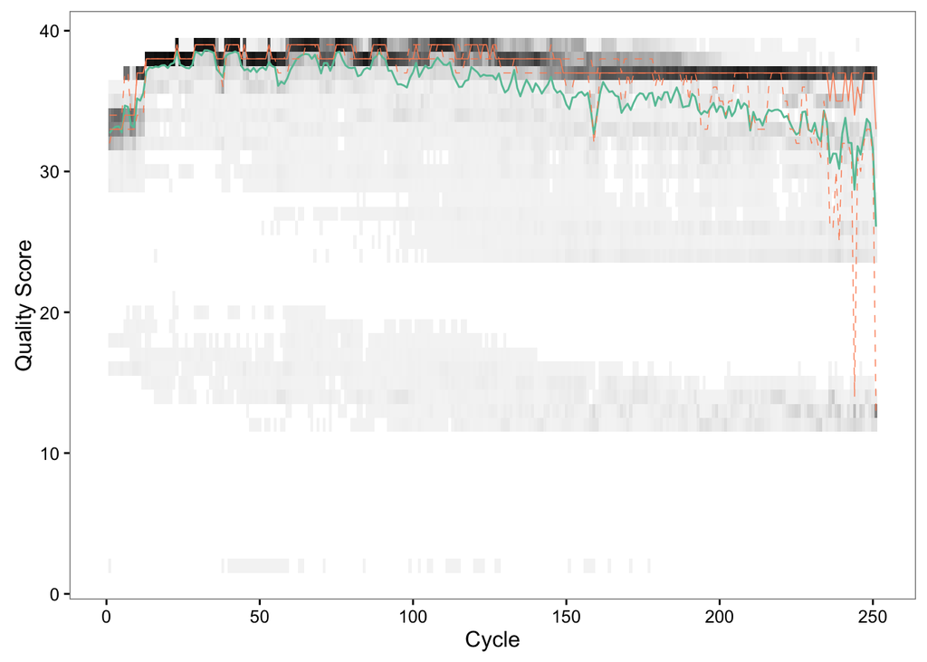

```r
plotQualityProfile(fnFs[[1]])
```

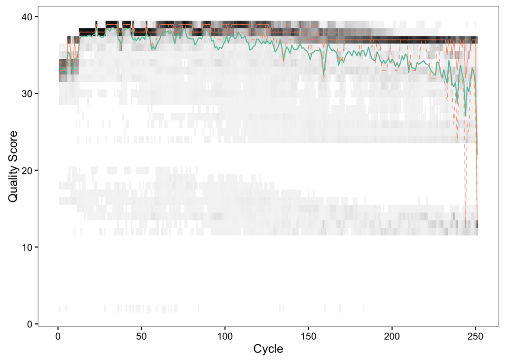

```r
plotQualityProfile(fnFs[[2]])
```

The forward reads are of good quality. It is generally a good idea to trim the first 10 bases of Illumina sequences, as error rates are higher and less well-controlled at the start of Illumina sequencing. It is also advisable to trim the very end, for similar reasons. There is no suggestion from the quality profiles that any additional trimming is needed, so for the forward reads we will trim the first 10 nucleotides and truncate at position 240 (trimming the last 10 nucleotides).

**Visualize the quality profile of the reverse reads**:

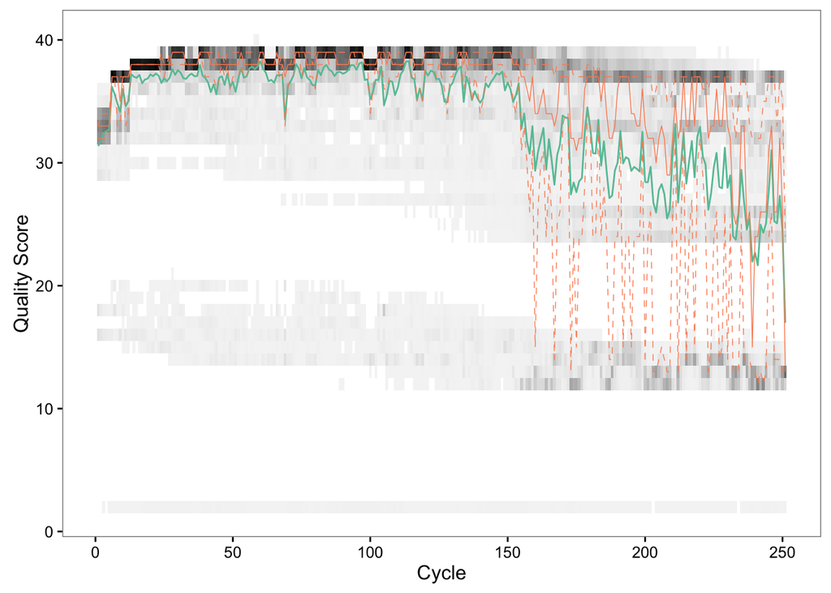

```r
plotQualityProfile(fnRs[[1]])
```

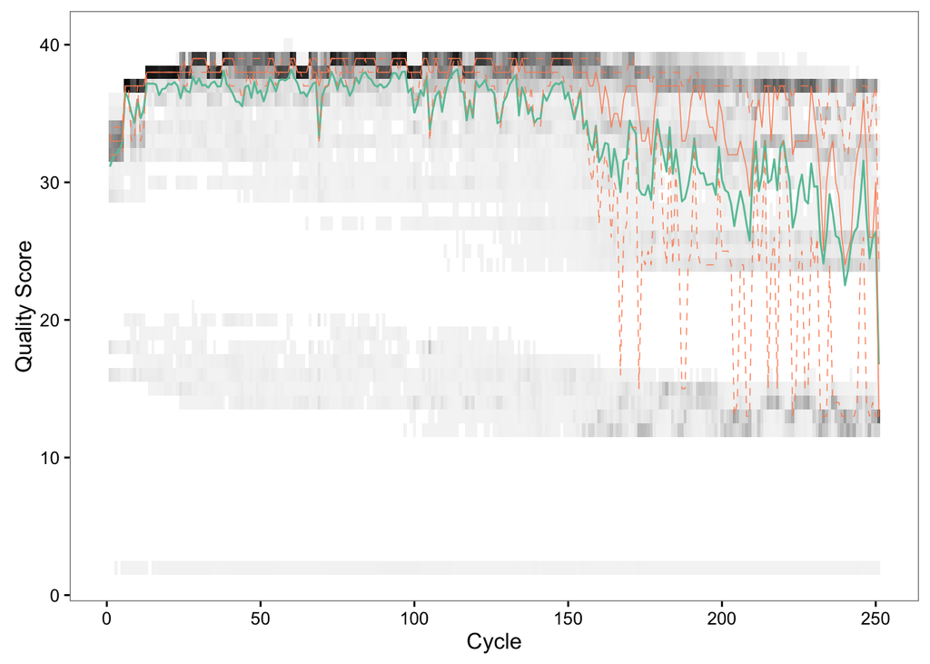

```r
plotQualityProfile(fnRs[[2]])
```

The reverse reads have significantly worse quality, especially towards the end of the reads, which is quite common in Illumina paired-end sequencing. This isn’t too worrisome, DADA2 incorporates quality information into its error model so the algorithm is fairly robust to lower quality sequence, but some trimming as the average qualities crash is still a good idea. Here we will trim the first 10 nucleotides (as standard) and truncate at position 160 where the quality distribution crashes.

## 2.3 Perform filtering and trimming

We chose our trimming parameters by inspecting the quality profiles. The filtering parameters we’ll use are standard: maxN=0 (DADA2 requires no Ns), truncQ=2 (quality score 2 in Illumina means “stop using this read”) and maxEE=2. The maxEE parameter sets the maximum number of “expected errors” allowed in a read. Setting a threshold on expected errors is [a better filter than simply averaging quality scores](http://www.drive5.com/usearch/manual/expected_errors.html). We use the fastqPairedFilter function to jointly filter the forward and reverse reads.

Further prepare file names

```r
# Make filenames for the filtered fastq files
dirFiltSeqs = file.path(dirname(path), "filtered_sequences")
if(!dir.exists(dirFiltSeqs)){
  dir.create(dirFiltSeqs)
}
(filtFs <- file.path(dirFiltSeqs, paste0(sample.names, "_F_filt.fastq.gz")))
```

```
##  [1] "MiSeq_SOP/filtered_sequences/F3D0_F_filt.fastq.gz"
##  [2] "MiSeq_SOP/filtered_sequences/F3D1_F_filt.fastq.gz"
##  [3] "MiSeq_SOP/filtered_sequences/F3D141_F_filt.fastq.gz"
##  [4] "MiSeq_SOP/filtered_sequences/F3D142_F_filt.fastq.gz"
##  [5] "MiSeq_SOP/filtered_sequences/F3D143_F_filt.fastq.gz"
##  [6] "MiSeq_SOP/filtered_sequences/F3D144_F_filt.fastq.gz"
##  [7] "MiSeq_SOP/filtered_sequences/F3D145_F_filt.fastq.gz"
##  [8] "MiSeq_SOP/filtered_sequences/F3D146_F_filt.fastq.gz"
##  [9] "MiSeq_SOP/filtered_sequences/F3D147_F_filt.fastq.gz"
## [10] "MiSeq_SOP/filtered_sequences/F3D148_F_filt.fastq.gz"
## [11] "MiSeq_SOP/filtered_sequences/F3D149_F_filt.fastq.gz"
## [12] "MiSeq_SOP/filtered_sequences/F3D150_F_filt.fastq.gz"
## [13] "MiSeq_SOP/filtered_sequences/F3D2_F_filt.fastq.gz"
## [14] "MiSeq_SOP/filtered_sequences/F3D3_F_filt.fastq.gz"
## [15] "MiSeq_SOP/filtered_sequences/F3D5_F_filt.fastq.gz"
## [16] "MiSeq_SOP/filtered_sequences/F3D6_F_filt.fastq.gz"
## [17] "MiSeq_SOP/filtered_sequences/F3D7_F_filt.fastq.gz"
## [18] "MiSeq_SOP/filtered_sequences/F3D8_F_filt.fastq.gz"
## [19] "MiSeq_SOP/filtered_sequences/F3D9_F_filt.fastq.gz"
## [20] "MiSeq_SOP/filtered_sequences/Mock_F_filt.fastq.gz"
```

```r
(filtRs <- file.path(dirFiltSeqs, paste0(sample.names, "_R_filt.fastq.gz")))
```

```
##  [1] "MiSeq_SOP/filtered_sequences/F3D0_R_filt.fastq.gz"
##  [2] "MiSeq_SOP/filtered_sequences/F3D1_R_filt.fastq.gz"
##  [3] "MiSeq_SOP/filtered_sequences/F3D141_R_filt.fastq.gz"
##  [4] "MiSeq_SOP/filtered_sequences/F3D142_R_filt.fastq.gz"
##  [5] "MiSeq_SOP/filtered_sequences/F3D143_R_filt.fastq.gz"
##  [6] "MiSeq_SOP/filtered_sequences/F3D144_R_filt.fastq.gz"
##  [7] "MiSeq_SOP/filtered_sequences/F3D145_R_filt.fastq.gz"
##  [8] "MiSeq_SOP/filtered_sequences/F3D146_R_filt.fastq.gz"
##  [9] "MiSeq_SOP/filtered_sequences/F3D147_R_filt.fastq.gz"
## [10] "MiSeq_SOP/filtered_sequences/F3D148_R_filt.fastq.gz"
## [11] "MiSeq_SOP/filtered_sequences/F3D149_R_filt.fastq.gz"
## [12] "MiSeq_SOP/filtered_sequences/F3D150_R_filt.fastq.gz"
## [13] "MiSeq_SOP/filtered_sequences/F3D2_R_filt.fastq.gz"
## [14] "MiSeq_SOP/filtered_sequences/F3D3_R_filt.fastq.gz"
## [15] "MiSeq_SOP/filtered_sequences/F3D5_R_filt.fastq.gz"
## [16] "MiSeq_SOP/filtered_sequences/F3D6_R_filt.fastq.gz"
## [17] "MiSeq_SOP/filtered_sequences/F3D7_R_filt.fastq.gz"
## [18] "MiSeq_SOP/filtered_sequences/F3D8_R_filt.fastq.gz"
## [19] "MiSeq_SOP/filtered_sequences/F3D9_R_filt.fastq.gz"
## [20] "MiSeq_SOP/filtered_sequences/Mock_R_filt.fastq.gz"
```

**Execute filtering of forward and reverse reads**:

```r
# Filter
for(i in seq_along(fnFs)) {
  fastqPairedFilter(fn = c(fnFs[i], fnRs[i]),
                    fout = c(filtFs[i], filtRs[i]),
                    trimLeft = c(10, 10),
                    truncLen = c(240,160),
                    maxN = 0,
                    maxEE = 2,
                    truncQ = 2,
                    compress = TRUE, verbose = TRUE)
}
```

```
## Overwriting file:MiSeq_SOP/filtered_sequences/F3D0_F_filt.fastq.gz
```

```
## Overwriting file:MiSeq_SOP/filtered_sequences/F3D0_R_filt.fastq.gz
```

```
## Read in 7793 paired-sequences, output 7124 filtered paired-sequences.
```

```
## Overwriting file:MiSeq_SOP/filtered_sequences/F3D1_F_filt.fastq.gz
```

```
## Overwriting file:MiSeq_SOP/filtered_sequences/F3D1_R_filt.fastq.gz
```

```
## Read in 5869 paired-sequences, output 5307 filtered paired-sequences.
```

```
## Overwriting file:MiSeq_SOP/filtered_sequences/F3D141_F_filt.fastq.gz
```

```
## Overwriting file:MiSeq_SOP/filtered_sequences/F3D141_R_filt.fastq.gz
```

```
## Read in 5958 paired-sequences, output 5472 filtered paired-sequences.
```

```
## Overwriting file:MiSeq_SOP/filtered_sequences/F3D142_F_filt.fastq.gz
```

```
## Overwriting file:MiSeq_SOP/filtered_sequences/F3D142_R_filt.fastq.gz
```

```
## Read in 3183 paired-sequences, output 2923 filtered paired-sequences.
```

```
## Overwriting file:MiSeq_SOP/filtered_sequences/F3D143_F_filt.fastq.gz
```

```
## Overwriting file:MiSeq_SOP/filtered_sequences/F3D143_R_filt.fastq.gz
```

```
## Read in 3178 paired-sequences, output 2951 filtered paired-sequences.
```

```
## Overwriting file:MiSeq_SOP/filtered_sequences/F3D144_F_filt.fastq.gz
```

```
## Overwriting file:MiSeq_SOP/filtered_sequences/F3D144_R_filt.fastq.gz
```

```
## Read in 4827 paired-sequences, output 4318 filtered paired-sequences.
```

```
## Overwriting file:MiSeq_SOP/filtered_sequences/F3D145_F_filt.fastq.gz
```

```
## Overwriting file:MiSeq_SOP/filtered_sequences/F3D145_R_filt.fastq.gz
```

```
## Read in 7377 paired-sequences, output 6757 filtered paired-sequences.
```

```
## Overwriting file:MiSeq_SOP/filtered_sequences/F3D146_F_filt.fastq.gz
```

```
## Overwriting file:MiSeq_SOP/filtered_sequences/F3D146_R_filt.fastq.gz
```

```
## Read in 5021 paired-sequences, output 4572 filtered paired-sequences.
```

```
## Overwriting file:MiSeq_SOP/filtered_sequences/F3D147_F_filt.fastq.gz
```

```
## Overwriting file:MiSeq_SOP/filtered_sequences/F3D147_R_filt.fastq.gz
```

```
## Read in 17070 paired-sequences, output 15673 filtered paired-sequences.
```

```
## Overwriting file:MiSeq_SOP/filtered_sequences/F3D148_F_filt.fastq.gz
```

```
## Overwriting file:MiSeq_SOP/filtered_sequences/F3D148_R_filt.fastq.gz
```

```
## Read in 12405 paired-sequences, output 11437 filtered paired-sequences.
```

```
## Overwriting file:MiSeq_SOP/filtered_sequences/F3D149_F_filt.fastq.gz
```

```
## Overwriting file:MiSeq_SOP/filtered_sequences/F3D149_R_filt.fastq.gz
```

```
## Read in 13083 paired-sequences, output 12049 filtered paired-sequences.
```

```
## Overwriting file:MiSeq_SOP/filtered_sequences/F3D150_F_filt.fastq.gz
```

```
## Overwriting file:MiSeq_SOP/filtered_sequences/F3D150_R_filt.fastq.gz
```

```
## Read in 5509 paired-sequences, output 5043 filtered paired-sequences.
```

```
## Overwriting file:MiSeq_SOP/filtered_sequences/F3D2_F_filt.fastq.gz
```

```
## Overwriting file:MiSeq_SOP/filtered_sequences/F3D2_R_filt.fastq.gz
```

```
## Read in 19620 paired-sequences, output 18106 filtered paired-sequences.
```

```
## Overwriting file:MiSeq_SOP/filtered_sequences/F3D3_F_filt.fastq.gz
```

```
## Overwriting file:MiSeq_SOP/filtered_sequences/F3D3_R_filt.fastq.gz
```

```
## Read in 6758 paired-sequences, output 6268 filtered paired-sequences.
```

```
## Overwriting file:MiSeq_SOP/filtered_sequences/F3D5_F_filt.fastq.gz
```

```
## Overwriting file:MiSeq_SOP/filtered_sequences/F3D5_R_filt.fastq.gz
```

```
## Read in 4448 paired-sequences, output 4060 filtered paired-sequences.
```

```
## Overwriting file:MiSeq_SOP/filtered_sequences/F3D6_F_filt.fastq.gz
```

```
## Overwriting file:MiSeq_SOP/filtered_sequences/F3D6_R_filt.fastq.gz
```

```
## Read in 7989 paired-sequences, output 7384 filtered paired-sequences.
```

```
## Overwriting file:MiSeq_SOP/filtered_sequences/F3D7_F_filt.fastq.gz
```

```
## Overwriting file:MiSeq_SOP/filtered_sequences/F3D7_R_filt.fastq.gz
```

```
## Read in 5129 paired-sequences, output 4770 filtered paired-sequences.
```

```
## Overwriting file:MiSeq_SOP/filtered_sequences/F3D8_F_filt.fastq.gz
```

```
## Overwriting file:MiSeq_SOP/filtered_sequences/F3D8_R_filt.fastq.gz
```

```
## Read in 5294 paired-sequences, output 4884 filtered paired-sequences.
```

```
## Overwriting file:MiSeq_SOP/filtered_sequences/F3D9_F_filt.fastq.gz
```

```
## Overwriting file:MiSeq_SOP/filtered_sequences/F3D9_R_filt.fastq.gz
```

```
## Read in 7070 paired-sequences, output 6514 filtered paired-sequences.
```

```
## Overwriting file:MiSeq_SOP/filtered_sequences/Mock_F_filt.fastq.gz
```

```
## Overwriting file:MiSeq_SOP/filtered_sequences/Mock_R_filt.fastq.gz
```

```
## Read in 4779 paired-sequences, output 4321 filtered paired-sequences.
```

We now have trimmed and filtered fastq files. The preceding filtering can be replaced by other filtering methods. However, in order for the later DADA2 mergePairs step to work, the filtered forward and reverse reads **must be in matched order**! The fastq files that come off the Illumina machine have this property, and fastqPairedFilter preserves it, but not all filtering tools do so.

# 3 Dereplicate sequences

In the dereplication step, all reads with identical sequences are combined into “unique sequences” with a corresponding abundance, i.e. the number of reads with that same sequence. Dereplication is a part of most pipelines because it reduces computation time by eliminating redundant comparisons between sequences.

Dereplication in the DADA2 pipeline has one crucial addition: **DADA2 retains a summary of the quality information associated with each unique sequence**. DADA2 constructs a “consensus” quality profile for each unique sequence by averaging the positional qualities from the dereplicated reads. These consensus quality profiles inform the error model of the subsequent denoising step, significantly increasing DADA2’s accuracy.

**Dereplicate the filtered fastq files**:

```r
derepFs <- derepFastq(filtFs, verbose=TRUE)
derepRs <- derepFastq(filtRs, verbose=TRUE)
# Name the derep-class objects by the sample names
names(derepFs) <- sample.names
names(derepRs) <- sample.names
```

Inspect the derep-class object returned by derepFastq:

```r
derepFs[[1]]
```

```
## derep-class: R object describing dereplicated sequencing reads
## $uniques: 7124 reads in 1860 unique sequences
##   Sequence lengths: min=230, median=230, max=230
## $quals: Quality matrix dimension:  1860 230
##   Consensus quality scores: min=12, median=37.75, max=39
## $map: Map from reads to unique sequences:  2 49 1 62 1 ...
```

Dereplicated sequences are stored in the $uniques integer vector, which is named by the unique sequence and valued by the abundance of that sequence. Consensus quality scores are stored in the $quals matrix: rows correspond to unique sequences and columns to nucleotide position. The $map vector maps the reads into the $uniques vector, and is used later when we merge the forward and reverse reads.

# 4 Denoise Sequences

We are now ready to apply DADA2’s core sequence denoising algorithm to the dereplicated sequences. This is the step where we infer the “real” amplicon sequences, as opposed to sequences that contain one or more errors.

First a key consideration: DADA2 depends on a parametric error model, and we do not know the error rates for this dataset. Fortunately, DADA2 can jointly infer the error-rate parameters and the composition of the sample, at the cost of additional computation time. This is done by implementing an EM-like algorithm in which the error rates and the set of true sequences are alternately estimated until convergence.

To perform this joint inference with `dada(...)` we pass it the `selfConsist=TRUE` flag (if `selfConsist=FALSE` it simply uses the provided error rates). As in many optimization problems, the algorithm must begin with an initial guess. For this we take a set of error rates estimated from another Miseq 2x250 sequencing run (called `tperr1`, included with the package) and inflate them, as it is better to start with error rates that are too high than too low.

**Perform joint sample inference and error rate estimation** (takes a few minutes):

```r
dadaFs <- dada(derepFs, err=inflateErr(tperr1,3), selfConsist = TRUE)
```

```
## Sample 1 - 7124 reads in 1860 unique sequences.
## Sample 2 - 5307 reads in 1540 unique sequences.
## Sample 3 - 5472 reads in 1413 unique sequences.
## Sample 4 - 2923 reads in 870 unique sequences.
## Sample 5 - 2951 reads in 898 unique sequences.
## Sample 6 - 4318 reads in 1224 unique sequences.
## Sample 7 - 6757 reads in 1688 unique sequences.
## Sample 8 - 4572 reads in 1370 unique sequences.
## Sample 9 - 15673 reads in 3419 unique sequences.
## Sample 10 - 11437 reads in 2625 unique sequences.
## Sample 11 - 12049 reads in 2903 unique sequences.
## Sample 12 - 5043 reads in 1501 unique sequences.
## Sample 13 - 18106 reads in 3489 unique sequences.
## Sample 14 - 6268 reads in 1408 unique sequences.
## Sample 15 - 4060 reads in 1144 unique sequences.
## Sample 16 - 7384 reads in 1759 unique sequences.
## Sample 17 - 4770 reads in 1126 unique sequences.
## Sample 18 - 4884 reads in 1301 unique sequences.
## Sample 19 - 6514 reads in 1609 unique sequences.
## Sample 20 - 4321 reads in 842 unique sequences.
##    selfConsist step 2
##    selfConsist step 3
##    selfConsist step 4
##    selfConsist step 5
##
##
## Convergence after  5  rounds.
```

```r
dadaRs <- dada(derepRs, err=inflateErr(tperr1,3), selfConsist = TRUE)
```

```
## Sample 1 - 7124 reads in 1563 unique sequences.
## Sample 2 - 5307 reads in 1283 unique sequences.
## Sample 3 - 5472 reads in 1288 unique sequences.
## Sample 4 - 2923 reads in 831 unique sequences.
## Sample 5 - 2951 reads in 847 unique sequences.
## Sample 6 - 4318 reads in 1246 unique sequences.
## Sample 7 - 6757 reads in 1747 unique sequences.
## Sample 8 - 4572 reads in 1208 unique sequences.
## Sample 9 - 15673 reads in 3273 unique sequences.
## Sample 10 - 11437 reads in 2394 unique sequences.
## Sample 11 - 12049 reads in 2686 unique sequences.
## Sample 12 - 5043 reads in 1374 unique sequences.
## Sample 13 - 18106 reads in 3132 unique sequences.
## Sample 14 - 6268 reads in 1353 unique sequences.
## Sample 15 - 4060 reads in 1106 unique sequences.
## Sample 16 - 7384 reads in 1589 unique sequences.
## Sample 17 - 4770 reads in 1050 unique sequences.
## Sample 18 - 4884 reads in 1120 unique sequences.
## Sample 19 - 6514 reads in 1449 unique sequences.
## Sample 20 - 4321 reads in 699 unique sequences.
##    selfConsist step 2
##    selfConsist step 3
##    selfConsist step 4
##    selfConsist step 5
##    selfConsist step 6
##
##
## Convergence after  6  rounds.
```

Inspecting the dada-class object returned by dada:

```r
dadaFs[[1]]
```

```
## dada-class: object describing DADA2 denoising results
## 129 sample sequences were inferred from 1860 input unique sequences.
## Key parameters: OMEGA_A = 1e-40, BAND_SIZE = 16, USE_QUALS = TRUE
```

The dada algorithm inferred 129 real variants from the 1860 unique sequences in the first sample. There is much more to the dada-class return object than this (see help(“dada-class”) for some info), including multiple diagnostics about the quality of each inferred sample sequence, but that is beyond the scope of an introductory tutorial. Let’s do one check on the quality of the error-rate estimation though before continuing.

**Visualize estimated error rates**:

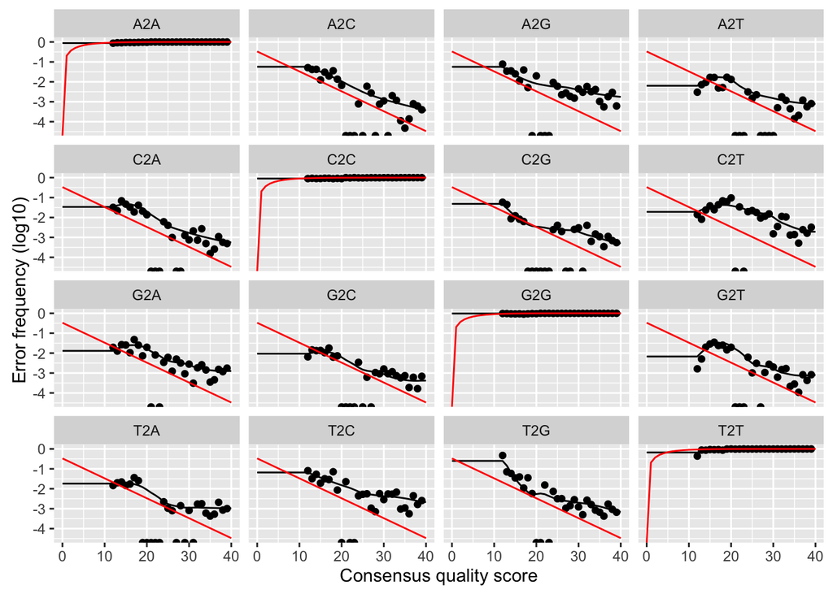

```r
plotErrors(dadaFs[[1]], nominalQ=TRUE)
```

The error rates for each possible transition (eg. A->C, A->G, …) are shown. The points are the observed error rates for each consensus quality score. The black line is the estimated error rates after convergence. The red line is the error rates expected under the nominal definition of the Q-value.

The black line (the estimated rates) seem to be fitting the observed rates well, and the error rates drop with increased quality as expected. Everything looks reasonable and we proceed with confidence.

# 5 Merge paired reads

The forward and reverse reads in this dataset are highly overlapping, which allows us to further reduce the error rate by merging those overlapping reads together. Note that in the DADA2 pipeline merging is perfomed **after** denoising the forward read and the reverse reads. The core function here is mergePairs, which depends on the forward and reverse reads being in matching order at the time they were dereplicated!

**Merge the denoised forward and reverse reads**:

```r
mergers <- mergePairs(dadaFs, derepFs, dadaRs, derepRs, verbose=TRUE)
# Inspect the merger data.frame from the first sample
head(mergers[[1]])
```

```
##                                                                                                                                                                                                                                      sequence
## s1_1 GCGAGCGTTATCCGGATTTATTGGGTTTAAAGGGTGCGCAGGCGGAAGATCAAGTCAGCG…
## s2_2 GCGAGCGTTATCCGGATTTATTGGGTTTAAAGGGTGCGTAGGCGGCCTGCCAAGTCAGCG…
## s3_4 GCGAGCGTTATCCGGATTTATTGGGTTTAAAGGGTGCGTAGGCGGGCTGTTAAGTCAGCG…
## s4_3 GCGAGCGTTATCCGGATTTATTGGGTTTAAAGGGTGCGTAGGCGGGCTTTTAAGTCAGCG…
## s5_6 GCGAGCGTTATCCGGATTTATTGGGTTTAAAGGGTGCGCAGGCGGACTCTCAAGTCAGCG…
## s6_5 GCGAGCGTTATCCGGATTTATTGGGTTTAAAGGGTGCGTAGGCGGGATGCCAAGTCAGCG…
##      abundance forward reverse nmatch nmismatch nindel prefer accept
## s1_1       587       1       1    148         0      0      1   TRUE
## s2_2       494       2       2    148         0      0      1   TRUE
## s3_4       452       3       4    148         0      0      1   TRUE
## s4_3       445       4       3    148         0      0      2   TRUE
## s5_6       353       5       6    148         0      0      1   TRUE
## s6_5       285       6       5    148         0      0      2   TRUE
```

We now have a data.frame for each sample with the merged $sequence, its $abundance, and the indices of the merged $forward and $reverse denoised sequences. Paired reads that did not exactly overlap were removed by mergePairs.

# 6 Construct sequence table

We can now construct a “sequence table” analogous to the “OTU table” produced by OTU methods.

We also drop the Mock community portion of the data at this point.

**Construct sequence table**:

```r
seqtab <- makeSequenceTable(mergers[names(mergers) != "Mock"])
```

```
## The sequences being tabled vary in length.
```

```r
dim(seqtab)
```

```
## [1]  19 268
```

```r
# Inspect distribution of sequence lengths
table(nchar(colnames(seqtab)))
```

```
##
## 231 232 233 234 235
##   1  83 178   5   1
```

The sequence table is a matrix with rows corresponding (and named by) the samples and columns corresponding to (and named by) the sequence variants. It is worth checking on the distribution of sequence lengths after merging. Here we see a narrow range of sequence lengths, as we expect. If some sequences are much longer or shorter than expected, it may be worth removing those sequences as they may be the result of non-specific priming.

# 7 Remove chimeras

The dada() algorithm removes substitution and indel errors, but it does not remove chimeras. That is, chimeras that were present in the sequenced sample are included in the sequence table we generated. Therefore, we now remove the chimeric sequences.

The accuracy of the sequences after the dada-denoising step makes identifying chimeras easier than it is when dealing with fuzzy OTUs. The DADA2 method to do this is by identifying all sequences which can be exactly reconstructred as a bimera (two-parent chimera) from more abundant sequences. See the help file ?isBimeraDenovo for more information.

**Remove chimeric sequences**:

```r
seqtab.nochim <- removeBimeraDenovo(seqtab, verbose=TRUE)
dim(seqtab.nochim)
```

```
## [1]  19 215
```

```r
sum(seqtab.nochim)/sum(seqtab)
```

```
## [1] 0.9636755
```

The fraction of chimeras varies based on factors including experimental procedures and sample complexity, but can be substantial. Here chimeras make up about 20% of the inferred sequence variants, but those variants account for <4% of the total sequence reads.

This is the final product of the core DADA2 pipeline: a sequence table that contains the counts of each denoised sequence variant in each sample.

# 8 Assign taxonomy

It is common at this point, especially in 16S or 18S amplicon sequencing, to classify denoised sequence variants taxonomically. The DADA2 package provides a native implementation of [the RDP’s naive Bayesian classifier](http://www.ncbi.nlm.nih.gov/pubmed/17586664) for this purpose. The assignTaxonomy(…) function takes a set of sequences and a training set of taxonomically classified sequences, and outputs the taxonomic assignments with at least minBoot bootstrap confidence.

Appropriately formatted training fasta files for

- the RDP training set 14,
- the GreenGenes 13.8 release clustered at 97% identity, and
- the Silva reference database

are [available for download here](https://www.dropbox.com/sh/mfcivbudmc21cqt/AAB1l-AUM5uKvjrR33ct-cTXa?dl=0).

Download the rdp_train_set_14.fa.gz file, and place it in the directory with the fastq files (if you don’t already have it).

**Assign taxonomy:**

```r
rdpFasta <- "MiSeq_SOP/raw_sequences/rdp_train_set_14.fa.gz"
taxa <- assignTaxonomy(seqtab.nochim, rdpFasta)
colnames(taxa) <- c("Kingdom", "Phylum", "Class", "Order", "Family", "Genus")
unname(head(taxa))
```

```
##      [,1]       [,2]            [,3]          [,4]
## [1,] "Bacteria" "Bacteroidetes" "Bacteroidia" "Bacteroidales"
## [2,] "Bacteria" "Bacteroidetes" "Bacteroidia" "Bacteroidales"
## [3,] "Bacteria" "Bacteroidetes" "Bacteroidia" "Bacteroidales"
## [4,] "Bacteria" "Bacteroidetes" "Bacteroidia" "Bacteroidales"
## [5,] "Bacteria" "Bacteroidetes" "Bacteroidia" "Bacteroidales"
## [6,] "Bacteria" "Bacteroidetes" "Bacteroidia" "Bacteroidales"
##      [,5]                 [,6]
## [1,] "Porphyromonadaceae" NA
## [2,] "Porphyromonadaceae" NA
## [3,] "Porphyromonadaceae" NA
## [4,] "Porphyromonadaceae" "Barnesiella"
## [5,] "Bacteroidaceae"     "Bacteroides"
## [6,] "Porphyromonadaceae" "Barnesiella"
```

Unsurprisingly, the Bacteroidetes are well represented among the top taxa in these fecal samples.

# 9 Evaluate accuracy

One of the provided samples was of a “mock community”, in which 20 known strains were mixed together and amplicon-sequenced (the mock community is supposed to be 21 strains, but P. acnes was absent in this instance). The reference sequences corresponding to these strains were provided along with the fastq files in the downloaded zip archive. We dropped the Mock sample when making our sequence table, but we can go back to that sample and compare the sequence variants inferred by DADA2 to the expected composition of the community.

**DADA2 accuracy on mock community**:

```r
unqs.mock <- getUniques(removeBimeraDenovo(mergers[["Mock"]], verbose=TRUE))
```

```
## Identified 0 bimeras out of 20 input sequences.
```

```r
cat("DADA2 inferred", length(unqs.mock), "sample sequences present in the Mock community.\n")
```

```
## DADA2 inferred 20 sample sequences present in the Mock community.
```

```r
mockRef <- readFasta("MiSeq_SOP/HMP_MOCK.v35.fasta.gz")
match.ref <- sum(sapply(names(unqs.mock), function(x) any(grepl(x, as.character(sread(mockRef))))))
cat("Of those,", sum(match.ref), "were exact matches to the expected reference sequences.\n")
```

```
## Of those, 20 were exact matches to the expected reference sequences.
```

This mock community dataset contained **20** bacterial strains. DADA2 found **20** unique sequences all of which **exactly** match the reference genomes of the expected community members. The residual error rate after the DADA2 pipeline is **0%**.

In comparison, when the Mothur pipeline is run on this same dataset, [it finds 35 OTUs in this Mock community sample](http://www.mothur.org/wiki/MiSeq_SOP#Assessing_error_rates). Not only is DADA2 inferring exact sequences instead of fuzzy 97% OTUs, it is making fewer false positive inferences than the OTU construction methods!

**Here ends the DADA2 portion of the tutorial**.

# 10 Bonus: Handoff to phyloseq

The DADA2 pipeline produced a sequence table and a taxonomy table which is appropriate for further analysis in phyloseq. We’ll also include the small amount of metadata we have – the samples are named by the gender (G), mouse subject number (X) and the day post-weaning (Y) it was sampled (eg. GXDY).

**Import into phyloseq**:

```r
library(phyloseq); packageVersion("phyloseq")
```

```
## [1] '1.16.2'
```

```r
library(ggplot2); packageVersion("ggplot2")
```

```
## [1] '2.1.0'
```

```r
# Make a data.frame holding the sample data
samples.out <- rownames(seqtab.nochim)
subject <- sapply(strsplit(samples.out, "D"), `[`, 1)
gender <- substr(subject,1,1)
subject <- substr(subject,2,999)
day <- as.integer(sapply(strsplit(samples.out, "D"), `[`, 2))
samdf <- data.frame(Subject=subject, Gender=gender, Day=day)
samdf$When <- "Early"
samdf$When[samdf$Day>100] <- "Late"
rownames(samdf) <- samples.out

# Construct phyloseq object (straightforward from dada2 outputs)
ps <- phyloseq(otu_table(seqtab.nochim, taxa_are_rows=FALSE),
               sample_data(samdf),
               tax_table(taxa))
ps
```

```
## phyloseq-class experiment-level object
## otu_table()   OTU Table:         [ 215 taxa and 19 samples ]
## sample_data() Sample Data:       [ 19 samples by 4 sample variables ]
## tax_table()   Taxonomy Table:    [ 215 taxa by 6 taxonomic ranks ]
```

We are now ready to use phyloseq.

**Visualize alpha-diversity**:

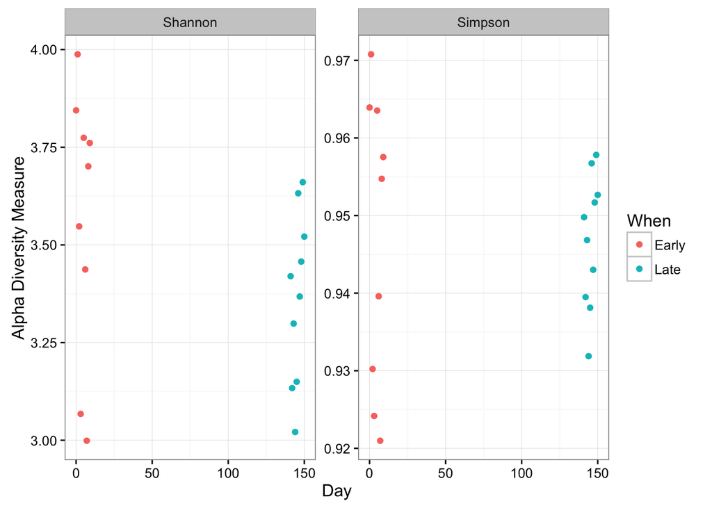

```r
plot_richness(ps, x="Day",
              measures=c("Shannon", "Simpson"), color="When") +
  theme_bw()
```

No obvious systematic difference in alpha-diversity between early and late samples.

**Ordinate**:

```r
ord.nmds.bray <- ordinate(ps, method="NMDS", distance="bray")
```

```
## Square root transformation
## Wisconsin double standardization
## *** Solution reached
```

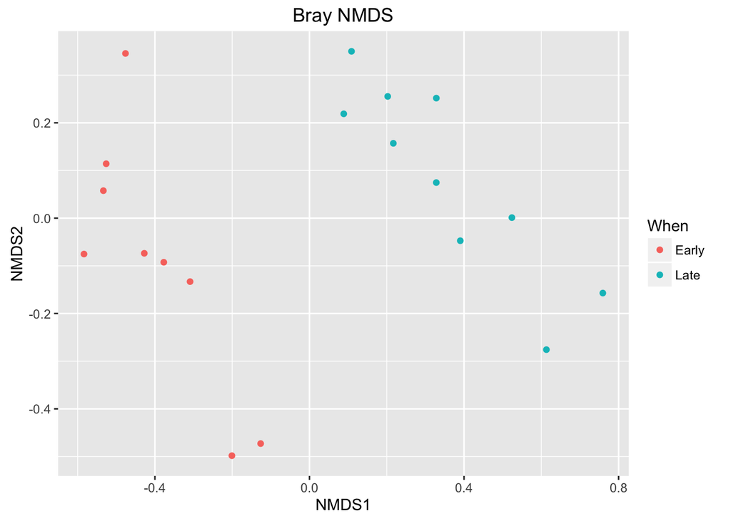

```r
plot_ordination(ps, ord.nmds.bray, color="When", title="Bray NMDS")
```

Ordination picks out a clear separation between the early and late samples.

**Bar plot**:

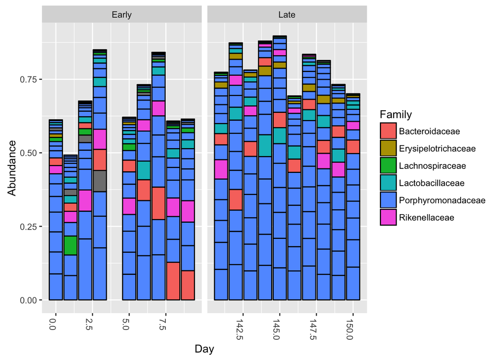

```r
top20 <- names(sort(taxa_sums(ps), decreasing=TRUE))[1:20]
ps.top20 <- transform_sample_counts(ps, function(OTU) OTU/sum(OTU))
ps.top20 <- prune_taxa(top20, ps.top20)
plot_bar(ps.top20, x="Day", fill="Family") + facet_wrap(~When, scales="free_x")
```

Nothing glaringly obvious jumps out from the taxonomic distribution of the top 20 sequences to explain the early-late differentiation.

This was just a bare bones demonstration of how the data from DADA2 can be easily imported into phyloseq and interrogated. For further examples on the many analyses possible with phyloseq, see [the phyloseq web site](https://joey711.github.io/phyloseq/)!